# Classification with Logistic Regression

CIS 241, Dr. Ladd

`spacebar` to go to the next slide, `esc`/menu to navigate

# What is Logistic Regression?

AKA Logit Regression, Maximum-Entropy Classification

Even though it’s got “Regression” in its name, Logistic Regression is our first *classification* method.

## How do we predict a *category*?

- Regressors predict a numerical value.
- Classifiers predict a category class.

Logistic Regression is a **classifier**.

## Logistic regression is a *linear* model.

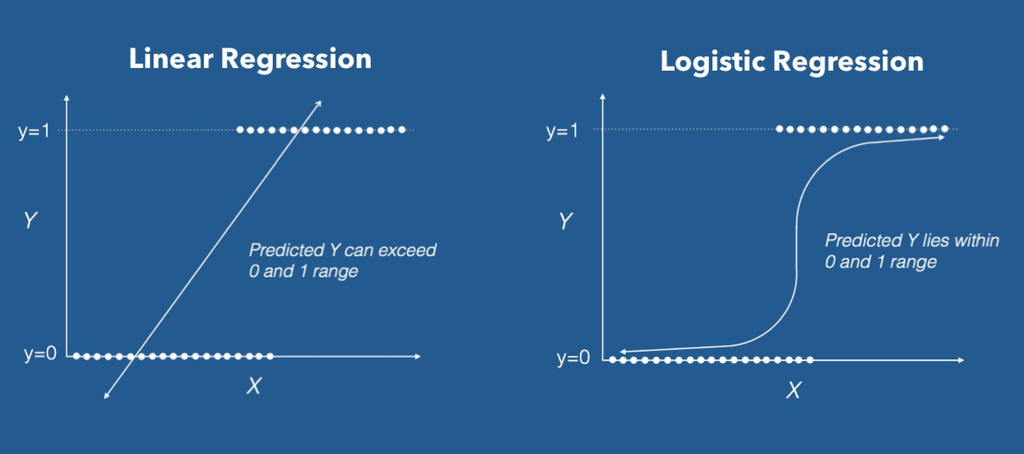

Image via Towards Data Science, Data Camp

## Instead of predicting a *value*, we predict the *probability of a category*.

## Traditional logistic regression is a *binary* classifier.

# Calculating Logistic Regression

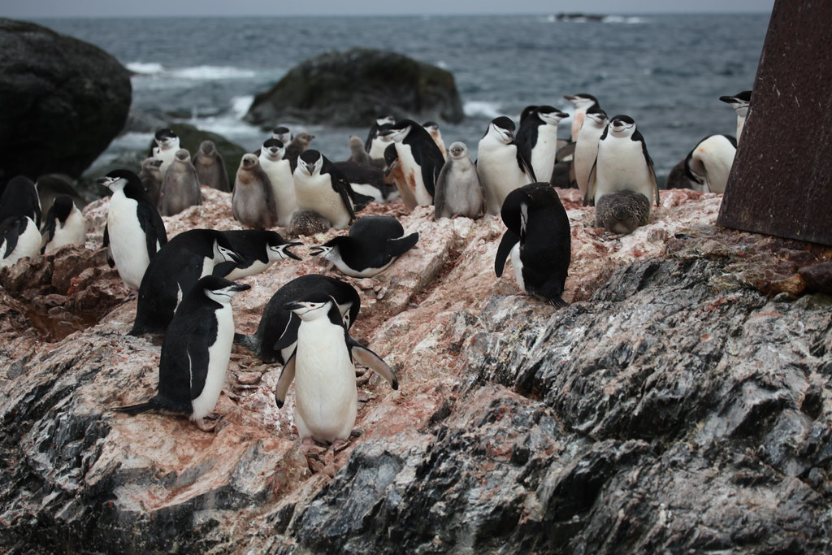

## Let’s create a model to classify penguins by species.

First, load in the `penguins` dataset in Seaborn.

```python
penguins = pd.read_csv("https://jrladd.com/CIS241/data/penguins.csv")
```

Now create a scatter plot showing two numeric variables from this dataset, using the `species` variable as different colors for the dots.

## Make this about just two variables.

We will learn to train a multiclass logistic regression later. For now, we should filter our data so we have just two variables. Let’s create a `gentoo_chinstrap` dataframe that has just those two species.

## Now let’s select some predictors.

Make a pairplot showing the relationship between all the numerical variables in this dataset. Also visualize the correlation matrix for the same variables.

Do we have any multicollinearity here? What should we do about it?

## Split the data into training and test sets.

This works just like it did for linear regression. We don’t have any categorical predictors this time, but that would be the same too.

Run the `train_test_split` function now. What should you use as a test size?

## Fit a logistic regression model

```python
# We need a different class from sklearn
from sklearn.linear_model import LogisticRegression
```

Do you need to drop null values?

## Setting model hyperparameters

- **penalty**: By default, scikit-learn regularizes your predictors. This could lead to unpredictable results for non-normalized data! For now, always set this to `None`.
- **solver**: This is the underlying algorithm scikit-learn will use to calculate the coefficients. The `lbfgs` solver is the default and is good for small datasets.
- **random_state**: As in `train_test_split`, this should always be set to ensure repeatability.

For more on this, read [Scikit-learns Defaults Are Wrong](https://ryxcommar.com/2019/08/30/scikit-learns-defaults-are-wrong/).

# Interpreting and Validating Logistic Regression Results

## We can print the intercept and the coefficents, just like in linear regression.

How do *the odds* change for each unit of the predictor?

## Instead of predicting a value, we can predict the *probability* that our new data will fall into category.

We need to store predictions, probabilities, and categories (i.e. classes).

## There is no RMSE or $R^{2}$ for logistic regression.

So how do we assess our model instead?

## Validate classifiers with the *confusion matrix*.

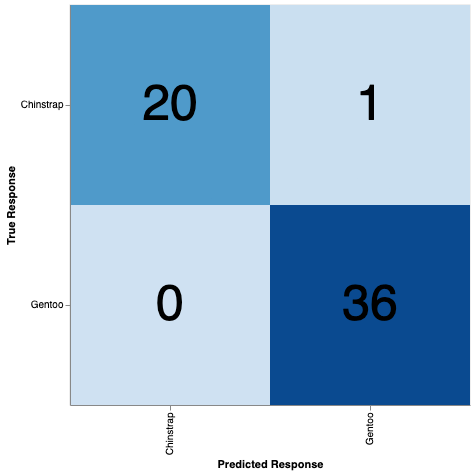

Confusion matrix for our penguin model.

## From the confusion matrix, we get scores for our model.

- **accuracy**: the proportion of cases classified correctly
- **precision**: the proportion of predicted values that are correct
- **recall**: the proportion of all values that are correctly classified
- **specificity**: the recall score for the other category

[figure not shown]

## Use the classfication report to get all of these metrics in scikit-learn.

There are individual functions for these, too.

## Cross-validation lets you compare multiple runs of the model with different training data.

This works the same as it did for regression, but it returns *accuracy* instead of $R^2$ score.

## Plot the model’s recall with the ROC Curve.

This only works for *binary* classifiers!

- ROC: Receiver Operating Characteristics
- AUC: Area Under the Curve (This measure is written right on the ROC Curve plot!)